# White Wine Quality EDA

Beltino Goncalves

12/03/2017

## Univariate Plots Section

```
##        X        fixed.acidity    volatile.acidity  citric.acid
##  Min.   :   1   Min.   : 3.800   Min.   :0.0800   Min.   :0.0000
##  1st Qu.:1225   1st Qu.: 6.300   1st Qu.:0.2100   1st Qu.:0.2700
##  Median :2450   Median : 6.800   Median :0.2600   Median :0.3200
##  Mean   :2450   Mean   : 6.855   Mean   :0.2782   Mean   :0.3342
##  3rd Qu.:3674   3rd Qu.: 7.300   3rd Qu.:0.3200   3rd Qu.:0.3900
##  Max.   :4898   Max.   :14.200   Max.   :1.1000   Max.   :1.6600
##  residual.sugar     chlorides       free.sulfur.dioxide
##  Min.   : 0.600   Min.   :0.00900   Min.   :  2.00
##  1st Qu.: 1.700   1st Qu.:0.03600   1st Qu.: 23.00
##  Median : 5.200   Median :0.04300   Median : 34.00
##  Mean   : 6.391   Mean   :0.04577   Mean   : 35.31
##  3rd Qu.: 9.900   3rd Qu.:0.05000   3rd Qu.: 46.00
##  Max.   :65.800   Max.   :0.34600   Max.   :289.00
##  total.sulfur.dioxide    density             pH          sulphates
##  Min.   :  9.0        Min.   :0.9871   Min.   :2.720   Min.   :0.2200
##  1st Qu.:108.0        1st Qu.:0.9917   1st Qu.:3.090   1st Qu.:0.4100
##  Median :134.0        Median :0.9937   Median :3.180   Median :0.4700
##  Mean   :138.4        Mean   :0.9940   Mean   :3.188   Mean   :0.4898
##  3rd Qu.:167.0        3rd Qu.:0.9961   3rd Qu.:3.280   3rd Qu.:0.5500
##  Max.   :440.0        Max.   :1.0390   Max.   :3.820   Max.   :1.0800
##     alcohol         quality
##  Min.   : 8.00   Min.   :3.000
##  1st Qu.: 9.50   1st Qu.:5.000
##  Median :10.40   Median :6.000
##  Mean   :10.51   Mean   :5.878
##  3rd Qu.:11.40   3rd Qu.:6.000
##  Max.   :14.20   Max.   :9.000
```

```
## 'data.frame':    4898 obs. of  13 variables:
##  $ X                   : int  1 2 3 4 5 6 7 8 9 10 ...
##  $ fixed.acidity       : num  7 6.3 8.1 7.2 7.2 8.1 6.2 7 6.3 8.1 ...
##  $ volatile.acidity    : num  0.27 0.3 0.28 0.23 0.23 0.28 0.32 0.27 0.3 0.22 ...
##  $ citric.acid         : num  0.36 0.34 0.4 0.32 0.32 0.4 0.16 0.36 0.34 0.43 ...
##  $ residual.sugar      : num  20.7 1.6 6.9 8.5 8.5 6.9 7 20.7 1.6 1.5 ...
##  $ chlorides           : num  0.045 0.049 0.05 0.058 0.058 0.05 0.045 0.045 0.049 0.044 ...
##  $ free.sulfur.dioxide : num  45 14 30 47 47 30 30 45 14 28 ...
##  $ total.sulfur.dioxide: num  170 132 97 186 186 97 136 170 132 129 ...
##  $ density             : num  1.001 0.994 0.995 0.996 0.996 ...
##  $ pH                  : num  3 3.3 3.26 3.19 3.19 3.26 3.18 3 3.3 3.22 ...
##  $ sulphates           : num  0.45 0.49 0.44 0.4 0.4 0.44 0.47 0.45 0.49 0.45 ...
##  $ alcohol             : num  8.8 9.5 10.1 9.9 9.9 10.1 9.6 8.8 9.5 11 ...
##  $ quality             : int  6 6 6 6 6 6 6 6 6 6 ...
```

```
##  [1] "X"                    "fixed.acidity"        "volatile.acidity"
##  [4] "citric.acid"          "residual.sugar"       "chlorides"
##  [7] "free.sulfur.dioxide"  "total.sulfur.dioxide" "density"
## [10] "pH"                   "sulphates"            "alcohol"
## [13] "quality"
```

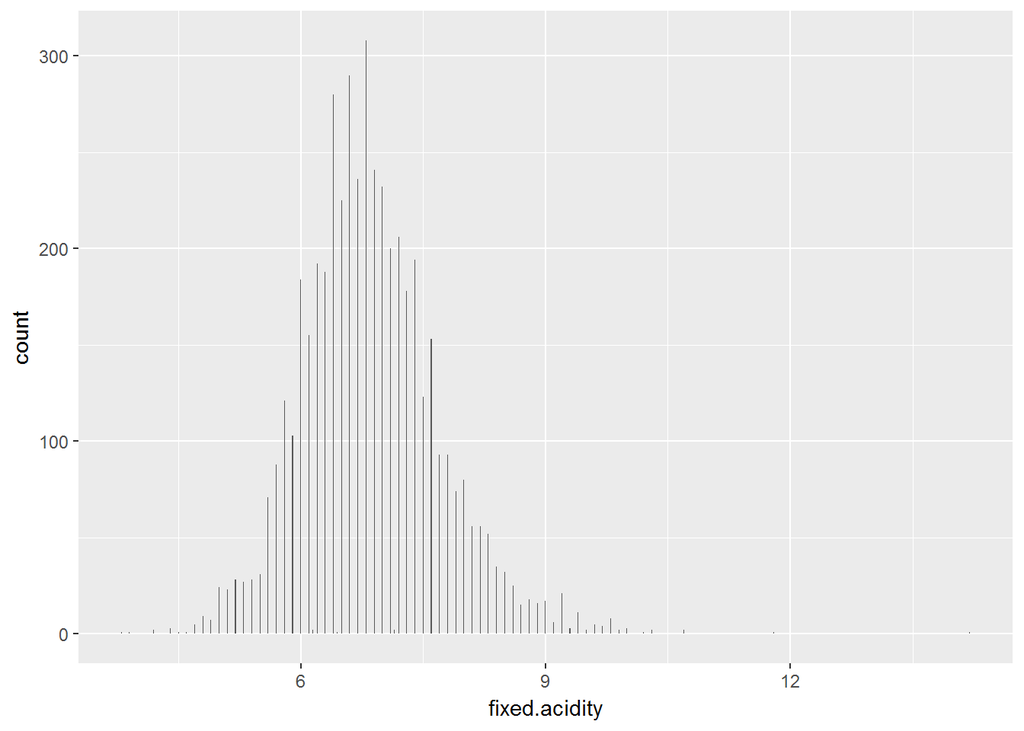

```
##    Min. 1st Qu.  Median    Mean 3rd Qu.    Max.
##   3.800   6.300   6.800   6.855   7.300  14.200
```

For the `Fixed Acidity` there appears to be normaly distributed, but there are a few outliears making our plot to be slightly positively skewed. This variable may be useful with PH for later investigation.

```
##  [1] "X"                    "fixed.acidity"        "volatile.acidity"
##  [4] "citric.acid"          "residual.sugar"       "chlorides"
##  [7] "free.sulfur.dioxide"  "total.sulfur.dioxide" "density"
## [10] "pH"                   "sulphates"            "alcohol"
## [13] "quality"
```

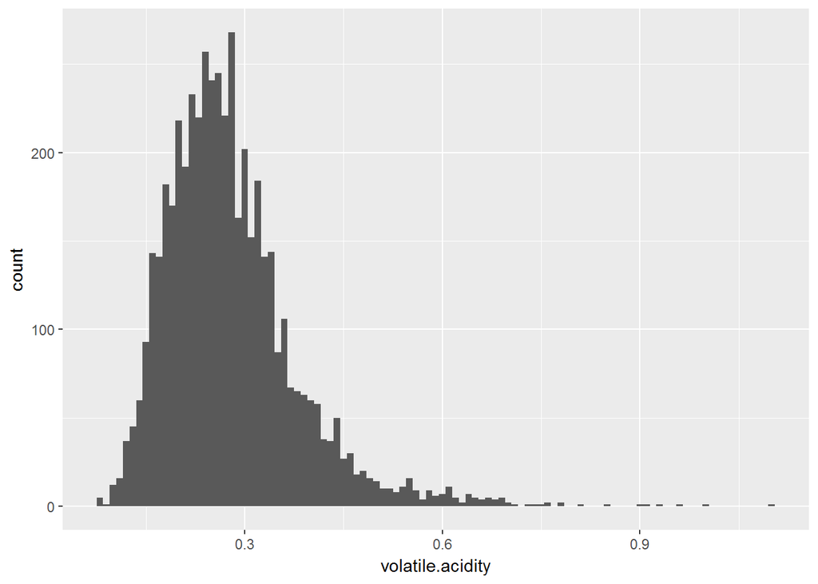

```
##    Min. 1st Qu.  Median    Mean 3rd Qu.    Max.
##  0.0800  0.2100  0.2600  0.2782  0.3200  1.1000
```

```
##  95%
## 0.46
```

For the `Volatile Acidity`, they appears to be normally distributed, with a positive skewedness. There are many outliears, and may have to subset the dataset from `Min. 0.0800 to .600`. This variable may be useful with variable `PH and fixed.acidity`for later investigation.

```
##  [1] "X"                    "fixed.acidity"        "volatile.acidity"
##  [4] "citric.acid"          "residual.sugar"       "chlorides"
##  [7] "free.sulfur.dioxide"  "total.sulfur.dioxide" "density"
## [10] "pH"                   "sulphates"            "alcohol"
## [13] "quality"
```

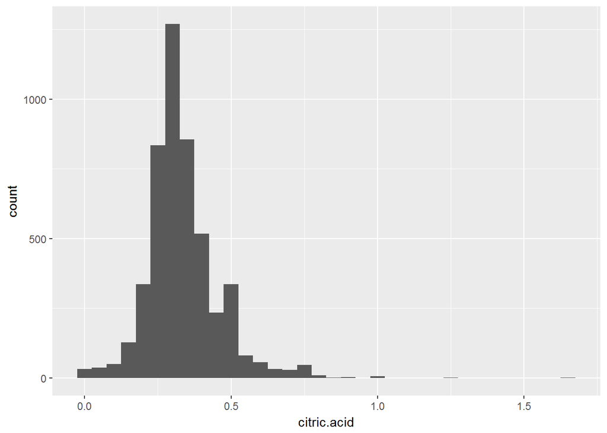

```
## 93%
## 0.5
```

```
##    Min. 1st Qu.  Median    Mean 3rd Qu.    Max.
##  0.0000  0.2700  0.3200  0.3342  0.3900  1.6600
```

The `Citric Acid` is normaly distributed, with a positive skewedness. There are a few outlies. This variable may be useful with variable `PH, fixed.acidity,and volatile.acidity` for later investigation.

```
##  [1] "X"                    "fixed.acidity"        "volatile.acidity"
##  [4] "citric.acid"          "residual.sugar"       "chlorides"
##  [7] "free.sulfur.dioxide"  "total.sulfur.dioxide" "density"
## [10] "pH"                   "sulphates"            "alcohol"
## [13] "quality"
```

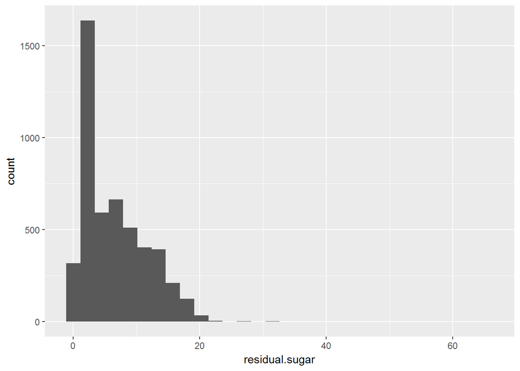

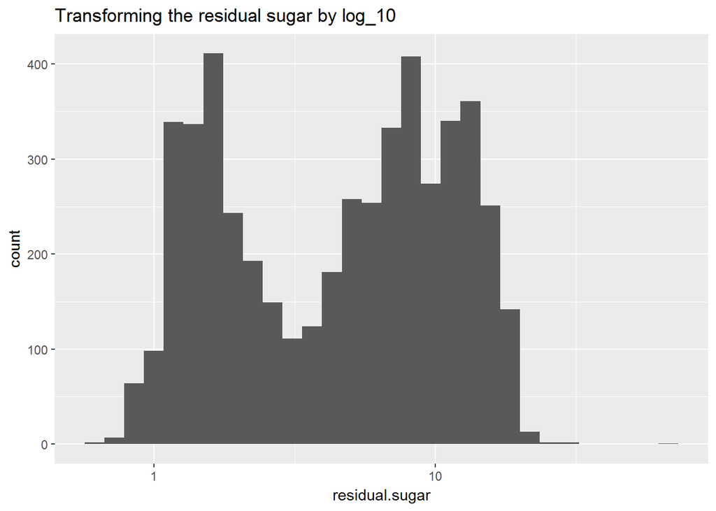

```
##    Min. 1st Qu.  Median    Mean 3rd Qu.    Max.
##   0.600   1.700   5.200   6.391   9.900  65.800
```

The `Residual Sugar` variable appears to have long tail and highly skewed, there are large ourlier in the high ranges `Max. 65.800`, so by tranformating and taking a log_10 may be useful for further analysis. Also, they appear to be highly skewed. This variable will be significantly imporant to determine the quality of the wine.

```
##  [1] "X"                    "fixed.acidity"        "volatile.acidity"
##  [4] "citric.acid"          "residual.sugar"       "chlorides"
##  [7] "free.sulfur.dioxide"  "total.sulfur.dioxide" "density"
## [10] "pH"                   "sulphates"            "alcohol"
## [13] "quality"
```

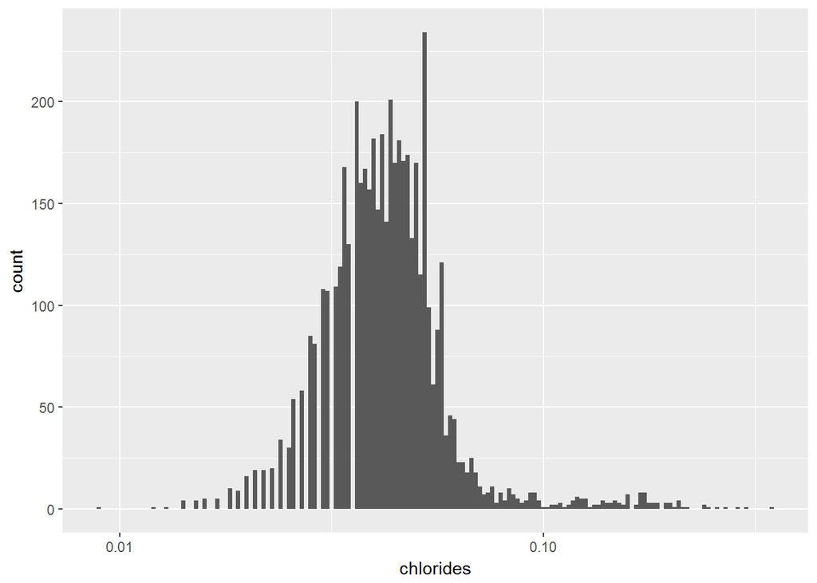

```
##    Min. 1st Qu.  Median    Mean 3rd Qu.    Max.
## 0.00900 0.03600 0.04300 0.04577 0.05000 0.34600
```

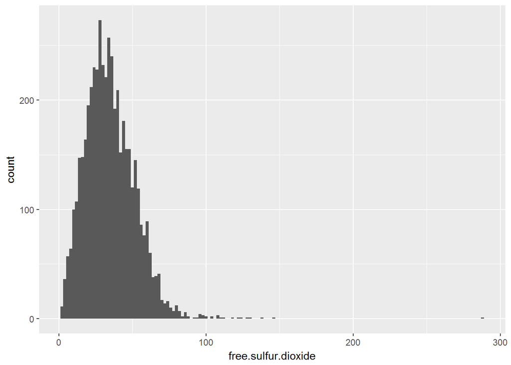

```
##    Min. 1st Qu.  Median    Mean 3rd Qu.    Max.
##    2.00   23.00   34.00   35.31   46.00  289.00
```

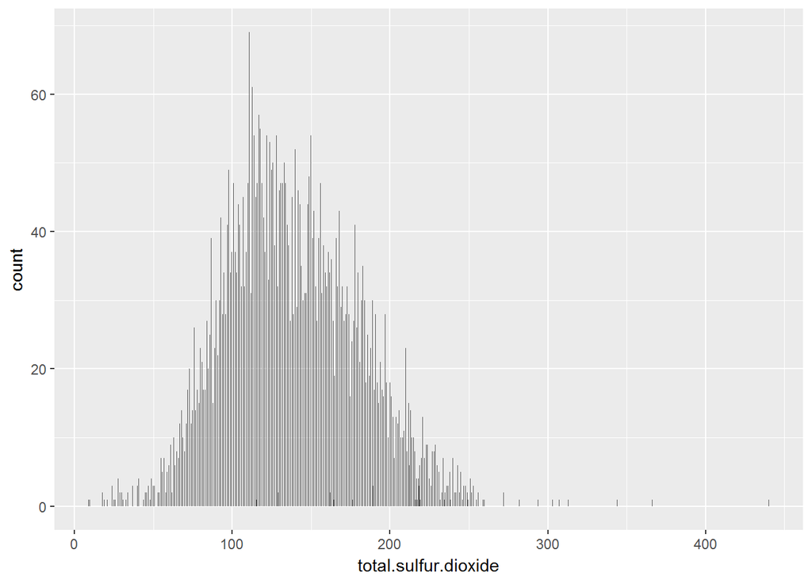

```
##    Min. 1st Qu.  Median    Mean 3rd Qu.    Max.
##     9.0   108.0   134.0   138.4   167.0   440.0
```

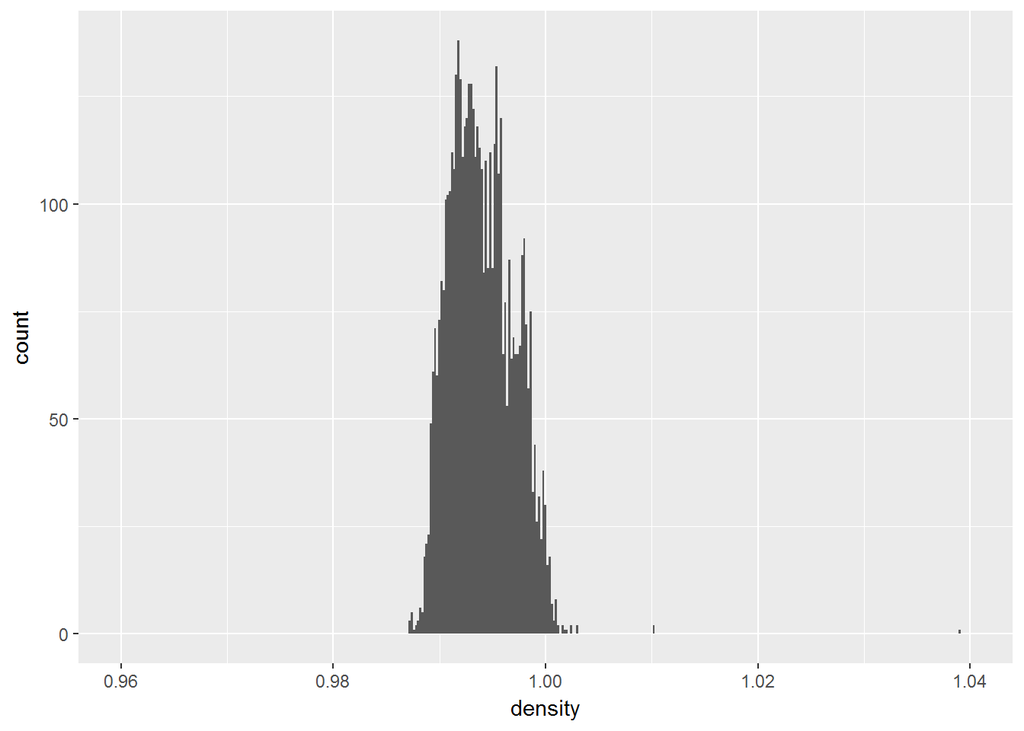

```
##    Min. 1st Qu.  Median    Mean 3rd Qu.    Max.
##  0.9871  0.9917  0.9937  0.9940  0.9961  1.0390
```

```
## [1] 0.98964
```

```
## [1] 1.0003
```

```
## [1] 0.002673078
```

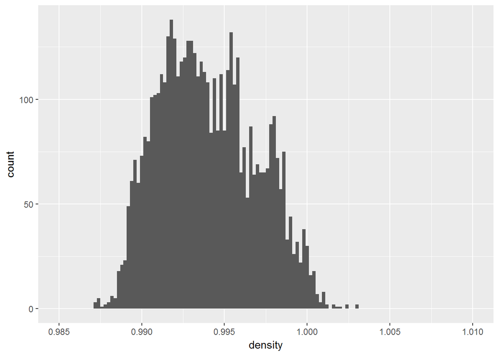

The `Density` variable had extreme outliers that had to be omitited. Althought the range of the standard deviation were very small, and the upper and lower bounds were also very close to eachother. Density and quality may have highly correlated variables.

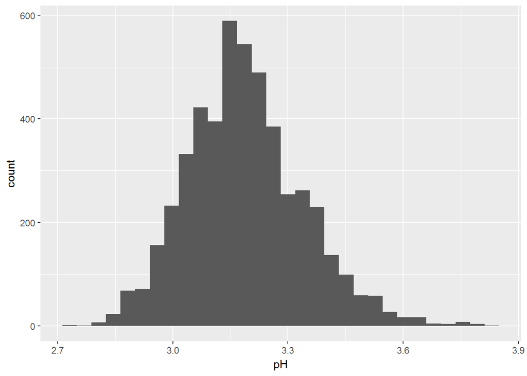

```
##    Min. 1st Qu.  Median    Mean 3rd Qu.    Max.
##   2.720   3.090   3.180   3.188   3.280   3.820
```

The `pH level` is normally distributed, there are not extreme outliers, and no skewness. The 1st quartile is 3.090 and 3rd quartile is 3.28, having a mean of 3.188.

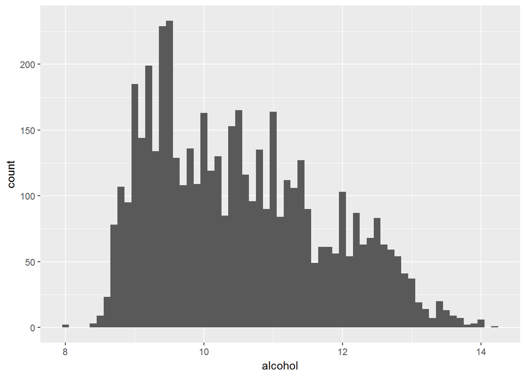

```
##    Min. 1st Qu.  Median    Mean 3rd Qu.    Max.
##    8.00    9.50   10.40   10.51   11.40   14.20
```

The `alchohol level` is normally distributed and appears to have positvely skewedness. There were nearly no outliers. I believe this is the most important variable in the model beside quality and it can determine the quality of the white wine. No experts qualified the quality of wines as 0, 1 or 2.

```
##  [1] "X"                    "fixed.acidity"        "volatile.acidity"
##  [4] "citric.acid"          "residual.sugar"       "chlorides"
##  [7] "free.sulfur.dioxide"  "total.sulfur.dioxide" "density"
## [10] "pH"                   "sulphates"            "alcohol"
## [13] "quality"
```

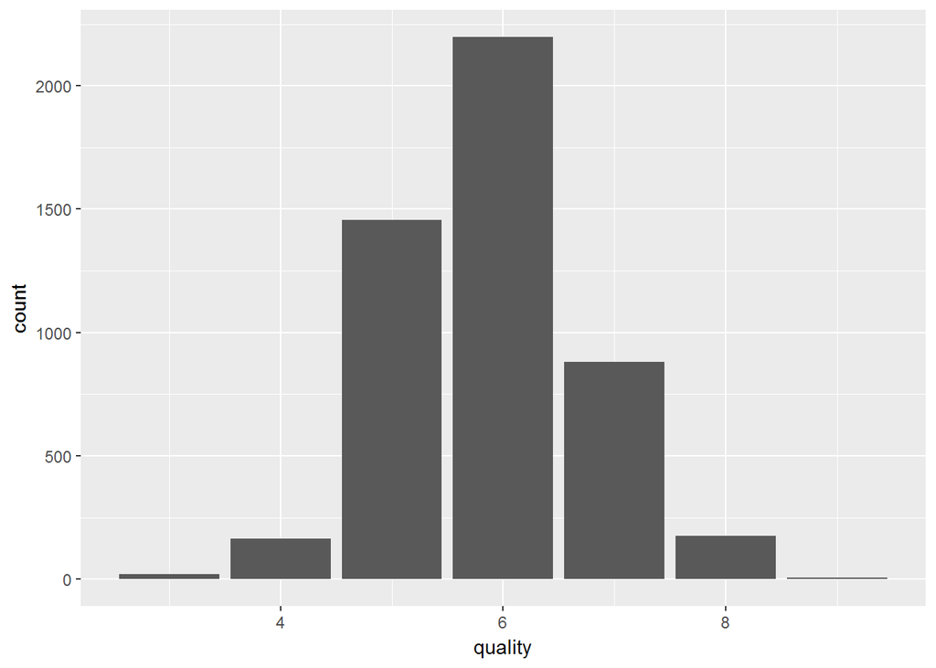

```
##    Min. 1st Qu.  Median    Mean 3rd Qu.    Max.
##   3.000   5.000   6.000   5.878   6.000   9.000
```

As expected `quality` variable is normally distributed. The mean is 5.878, meadian is 6.000, while the 1st quartile is 5.000 and 3rd quartile is 6.00. Later in my analysis I’m going to compare the quality variable with nearly ph and alcohol level to predict which white wine gets the high quality ranks from the experts.

## Univeriet Analysis.

### The Structure of the dataset

The white wine dataset contains 4,898 white wines with 11 variables(fixed acidity, volatile acidity, citric acid, residual sugar, chlorides, free sulfur dioxide, total sulfur dioxide, density, pH, sulphates,alcohol) on quantifying the chemical properties of each wine. At least 3 wine experts rated the quality of each wine, providing a rating between 0 (very bad) and 10 (very excellent). The dataset has no missing values.

### Main features that I am Interested for Research.

The main features in the dataset are Alchohol, Density, Residual Sugar. I do not think that all variables in our dataset are significant enough to predict the quality of White Wine. I’d be interested in determining which features are more significant to product the quality.

### Other features in the dataset that would help support our investigations.

The Acidity features (i,e Fixed Acidity, Volatile Acidity and Citric Acid) may also be significant for the research of the quality as well as the pH leve of the White Wines.

### Any new variables from existing vriables in the dataset.

I created a factor variable from the quality attribute and some buckets in the future part of the research.

### Unusual distributions, operations to Tidy, Adjust, or change the form of the data.

I made a log_10 transformation to Residual Sugar since it is highly skewed, which now it looks more like a bimodal distribution with two peaks. There are also variables that has outliers, and had to limits the x axis to get rid of the extreme outliers. This will allow us to interepret our visualization better.

## Bivariate Plots Section

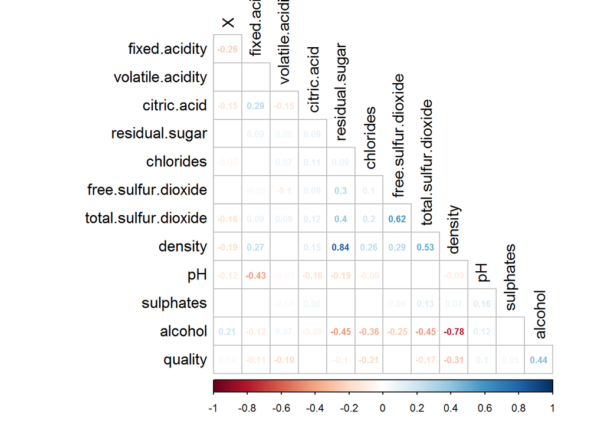

The `blank` boxes denotes variables that has no significant p-values. The pairs Residual Sugar & Density and Alchohol & Density pairs have strong correlations, While there are weaker correlations in Quality & Alchohol and Quality & Density.

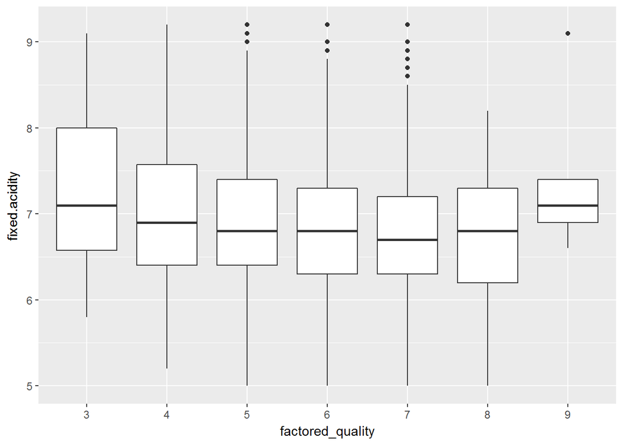

```
##
##  Pearson's product-moment correlation
##
## data:  df$quality and df$fixed.acidity
## t = -8.005, df = 4896, p-value = 1.48e-15
## alternative hypothesis: true correlation is not equal to 0
## 95 percent confidence interval:
##  -0.14121974 -0.08592991
## sample estimates:
##        cor
## -0.1136628
```

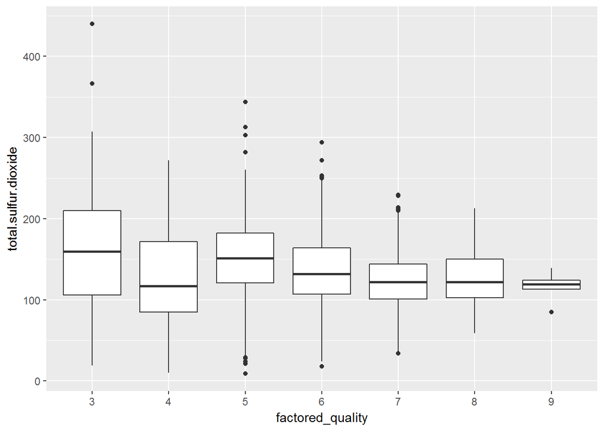

```
##
##  Pearson's product-moment correlation
##
## data:  df$quality and df$total.sulfur.dioxide
## t = -12.418, df = 4896, p-value < 2.2e-16
## alternative hypothesis: true correlation is not equal to 0
## 95 percent confidence interval:
##  -0.2017563 -0.1474524
## sample estimates:
##        cor
## -0.1747372
```

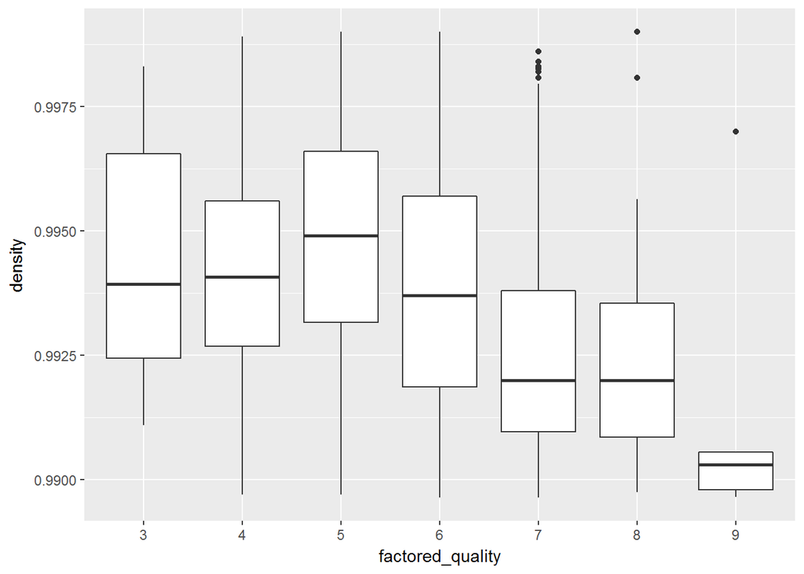

```
## [1] -0.3071233
```

We omitted the lowest 5% and highiest 95% to make our visualization better. There is a weak negative correlation between Density and Quality at -0.3071. Therefore Density may have an significant effect to predict Quality of White Wine. The visualization does show an very remarkable story based on the quality of the density.

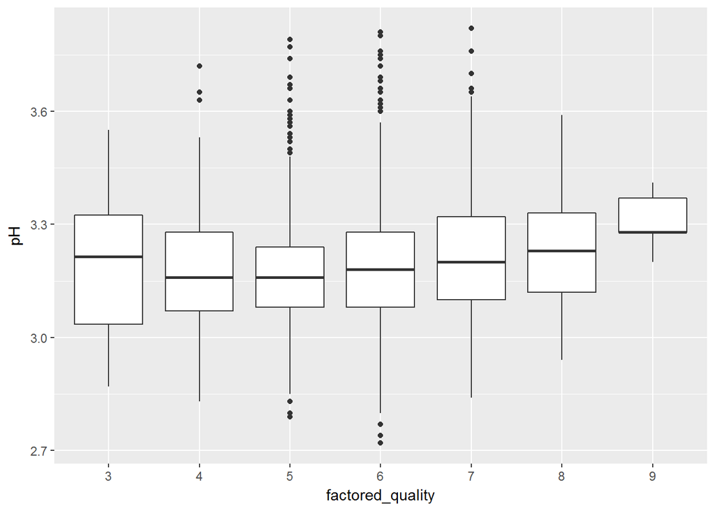

```
## [1] 0.09942725
```

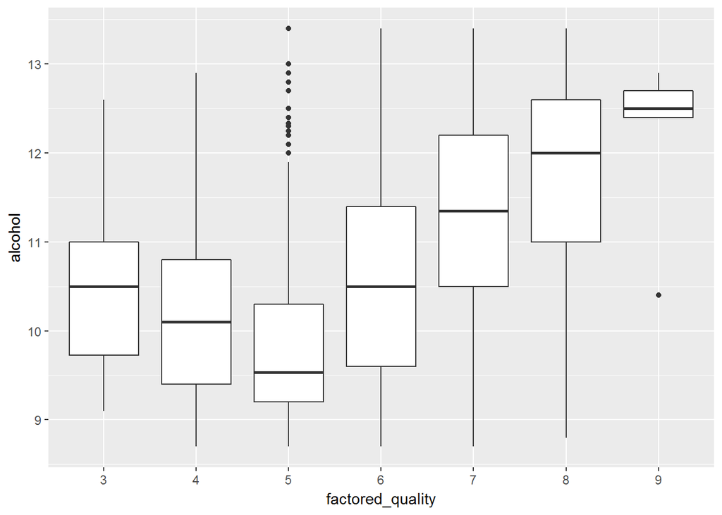

```
##
##  Pearson's product-moment correlation
##
## data:  df$quality and df$alcohol
## t = 33.858, df = 4896, p-value < 2.2e-16
## alternative hypothesis: true correlation is not equal to 0
## 95 percent confidence interval:
##  0.4126015 0.4579941
## sample estimates:
##       cor
## 0.4355747
```

There are some pairs that have strong correlation and using scatter plots allows us to better understand their correlation.

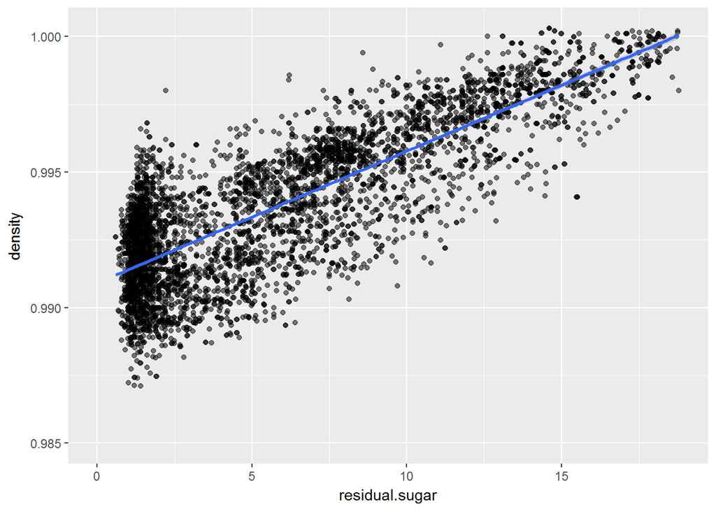

```
##
##  Pearson's product-moment correlation
##
## data:  df$density and df$residual.sugar
## t = 107.87, df = 4896, p-value < 2.2e-16
## alternative hypothesis: true correlation is not equal to 0
## 95 percent confidence interval:
##  0.8304732 0.8470698
## sample estimates:
##       cor
## 0.8389665
```

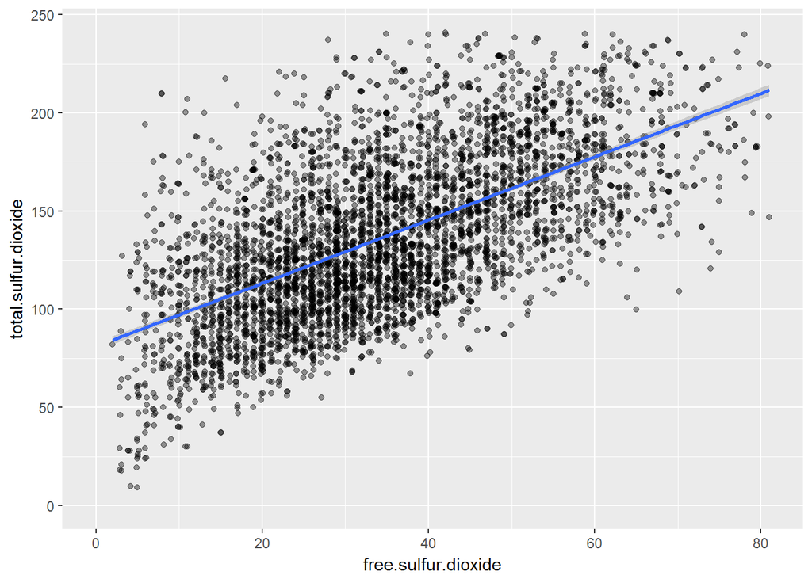

```
##
##  Pearson's product-moment correlation
##
## data:  df$free.sulfur.dioxide and df$total.sulfur.dioxide
## t = 54.645, df = 4896, p-value < 2.2e-16
## alternative hypothesis: true correlation is not equal to 0
## 95 percent confidence interval:
##  0.5977994 0.6326026
## sample estimates:
##      cor
## 0.615501
```

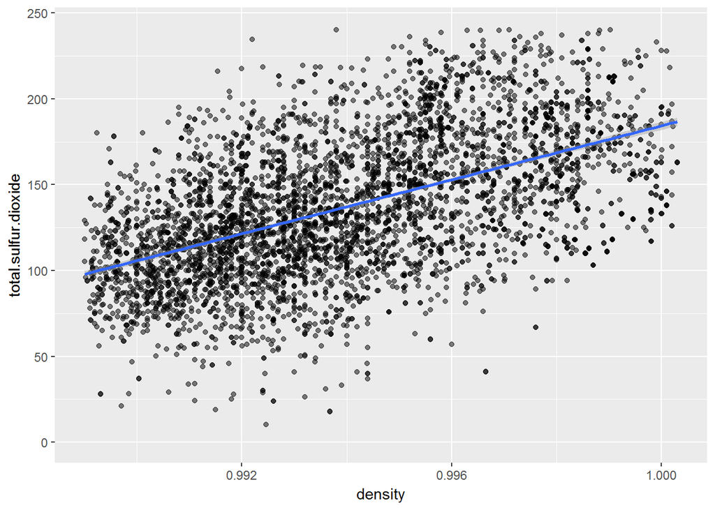

```
##
##  Pearson's product-moment correlation
##
## data:  df$density and df$total.sulfur.dioxide
## t = 43.719, df = 4896, p-value < 2.2e-16
## alternative hypothesis: true correlation is not equal to 0
## 95 percent confidence interval:
##  0.5094349 0.5497297
## sample estimates:
##       cor
## 0.5298813
```

# Bivariate Analysis

### General Observation Investigated

The white wine quality in the range of 3-5 with a less alcohol, implies a better quality, while the quality in the range of 6-9 with more alcohol refers to a better quality. This same relation can be also seen in pH with less variance. Despite the fact of Fixed Acidity and pH are the same, Fixed Acidity only ensures the relation, less of the Fixed Acidity refers to better quality in the quality range of 3-5. Density also has an interesting effect. The quality range from 3-5 has more density for the better quality, while the better quality in the quality range of 6 - 9 has a less density according to the related boxplot. I believe that too much alcohol and pH, can affect Quality in a negative way. As result of these affects, both too little and too much of any attributes can lower the quality of white wine, and this may cause our model to be have issues with overfitting when building a linear model.

### Strongest Relationship

The most compelling relationship one is between density and residual sugar, followed by alcohol - density. However, there is a weak correlation, since density and alcohol are the only ones that are directly correlated with Quality. Also, by having residual sugar already correlated with density, it may have an effect on Quality.

# Multivariate Plots Sections

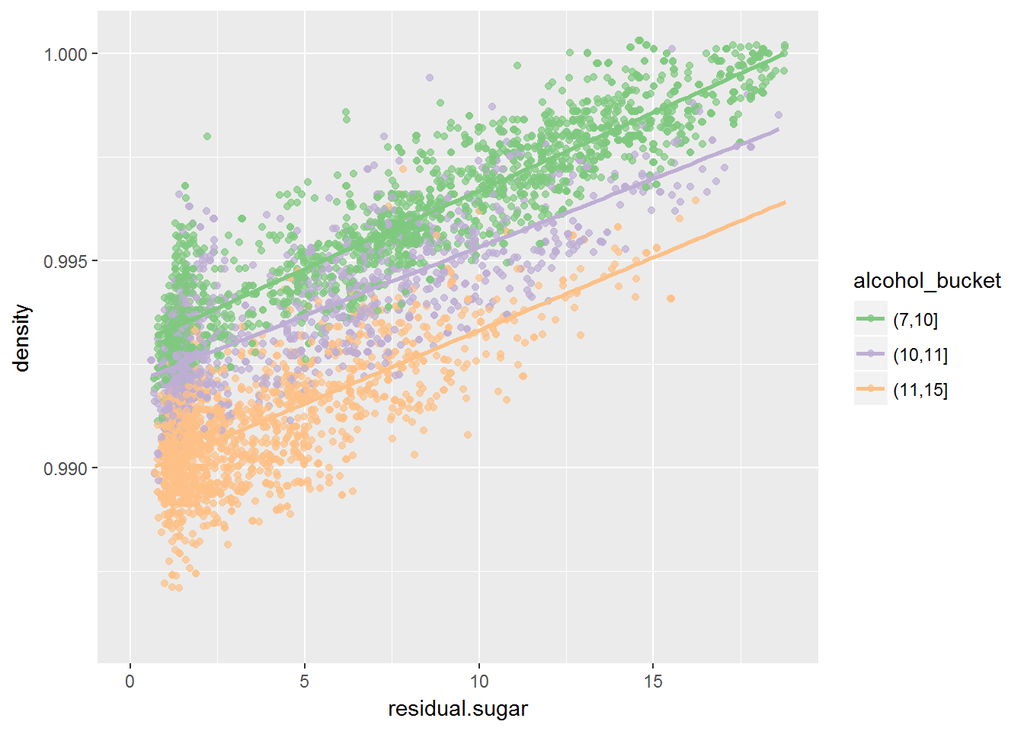

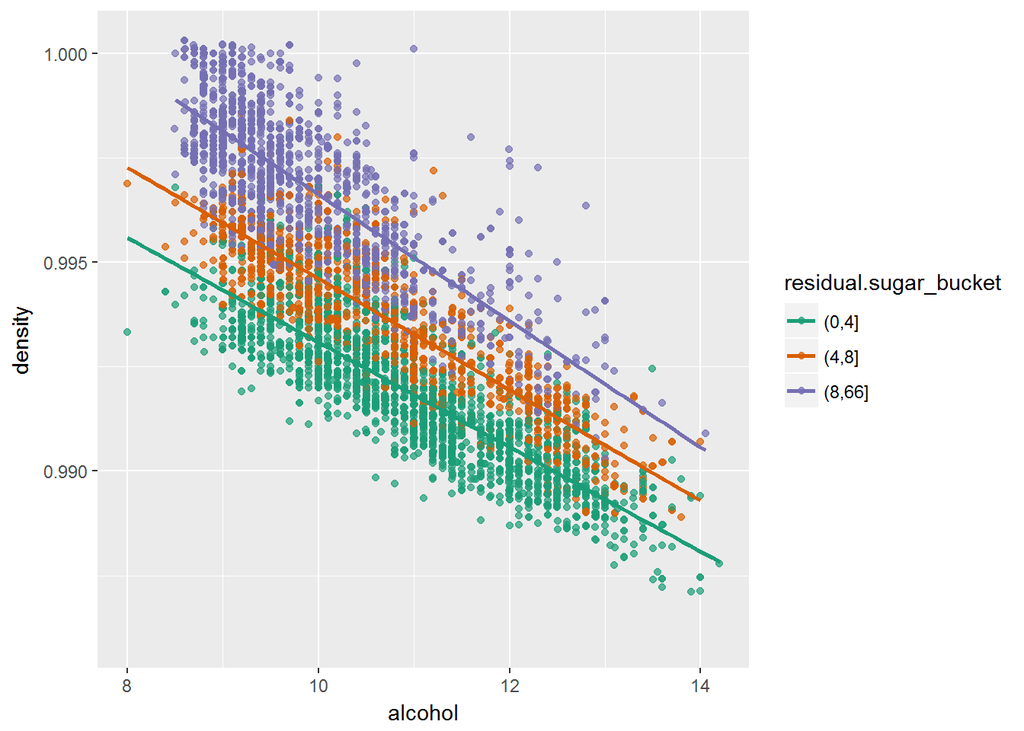

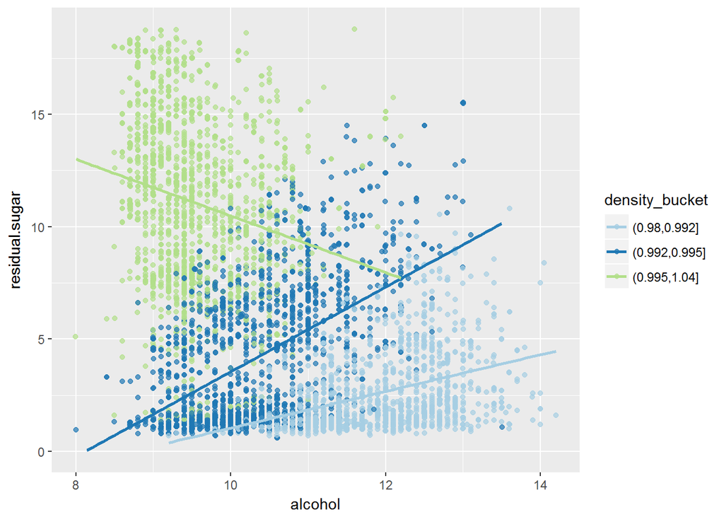

It appears that these variables have significant effects among each other, and has a strong correlation. The three scatter plots above, can easily distinguish the clusters. Thus showing obvious clusters for density, alcohol and residual sugar, with some pairs that are highly correlated. Alchohol has the most correlated pairs, and it is the only one that is highly correlated with quality, which it is to believe that alcohol’s pairs may have some effects on quality.

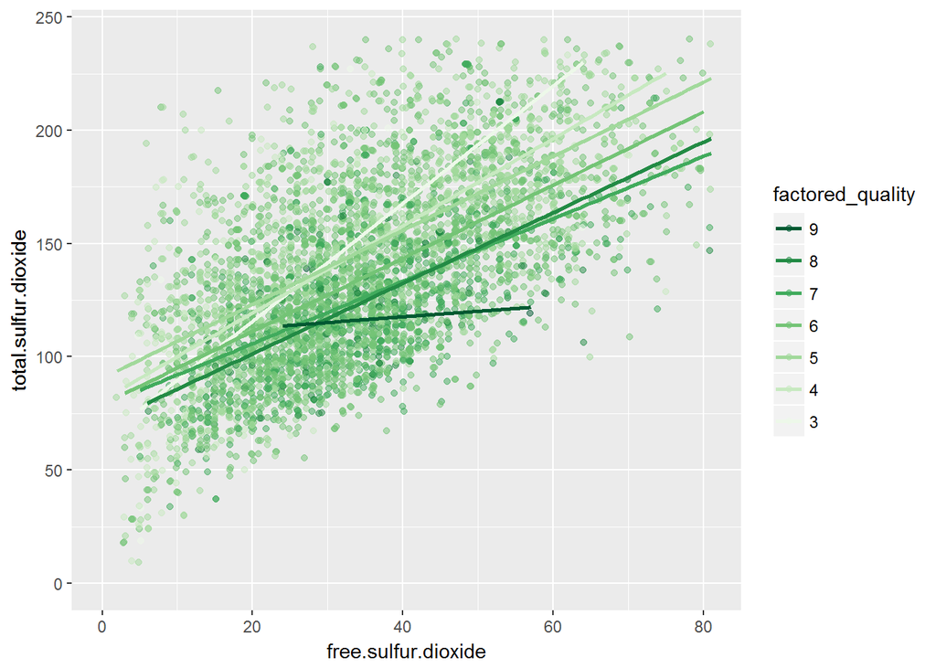

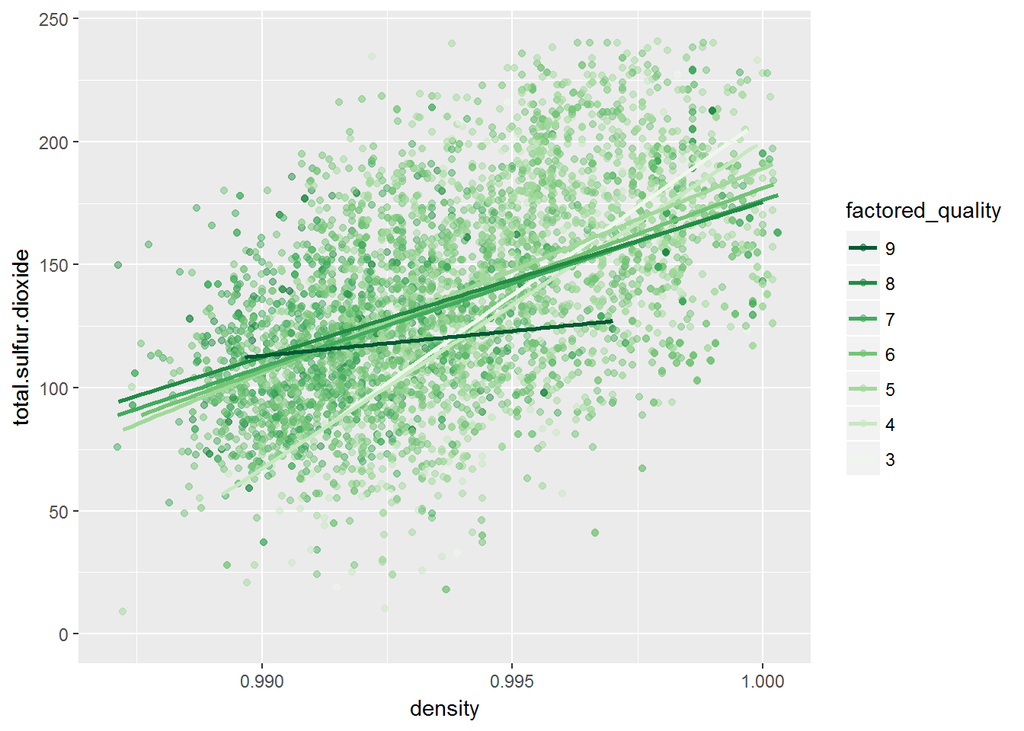

```
##                      free.sulfur.dioxide total.sulfur.dioxide    density
## free.sulfur.dioxide          1.000000000            0.6155010  0.2942104
## total.sulfur.dioxide         0.615500965            1.0000000  0.5298813
## density                      0.294210411            0.5298813  1.0000000
## quality                      0.008158067           -0.1747372 -0.3071233
##                           quality
## free.sulfur.dioxide   0.008158067
## total.sulfur.dioxide -0.174737218
## density              -0.307123313
## quality               1.000000000
```

One can assume that there might be more of an heterogeneous distributions or an diversed cluster based on the quality pairs, but their is none. Therefore building a predictive model would be harder than I had thought. Quality factors are also homogeneously distributed in these two moderately correlated pairs.

```
##
## Calls:
## m1: lm(formula = quality ~ alcohol, data = df)
## m2: lm(formula = quality ~ alcohol + density, data = df)
## m3: lm(formula = quality ~ alcohol + density + residual.sugar, data = df)
## m4: lm(formula = quality ~ alcohol + density + residual.sugar + pH,
##     data = df)
## m5: lm(formula = quality ~ alcohol + density + residual.sugar + pH +
##     volatile.acidity, data = df)
## m6: lm(formula = quality ~ alcohol + density + residual.sugar + pH +
##     volatile.acidity + free.sulfur.dioxide, data = df)
##
## ===========================================================================================================
##                             m1            m2            m3            m4            m5            m6
## -----------------------------------------------------------------------------------------------------------
##   (Intercept)              2.582***    -22.492***     90.313***    116.411***     97.650***     93.231***
##                           (0.098)       (6.165)      (12.374)      (12.781)      (12.392)      (12.387)
##   alcohol                  0.313***      0.360***      0.246***      0.209***      0.253***      0.265***
##                           (0.009)       (0.015)       (0.018)       (0.019)       (0.018)       (0.018)
##   density                               24.728***    -87.886***   -115.741***    -96.535***    -92.224***
##                                         (6.079)      (12.317)      (12.791)      (12.404)      (12.397)
##   residual.sugar                                       0.053***      0.066***      0.064***      0.059***
##                                                       (0.005)       (0.005)       (0.005)       (0.005)
##   pH                                                                 0.596***      0.528***      0.495***
##                                                                     (0.079)       (0.076)       (0.076)
##   volatile.acidity                                                                -2.024***     -1.965***
##                                                                                   (0.109)       (0.109)
##   free.sulfur.dioxide                                                                            0.004***
##                                                                                                 (0.001)
## -----------------------------------------------------------------------------------------------------------
##   R-squared                0.190         0.192         0.210         0.219         0.271         0.275
##   adj. R-squared           0.190         0.192         0.210         0.219         0.270         0.274
##   sigma                    0.797         0.796         0.787         0.783         0.757         0.754
##   F                     1146.395       583.290       434.085       343.516       363.847       309.484
##   p                        0.000         0.000         0.000         0.000         0.000         0.000
##   Log-likelihood       -5839.391     -5831.127     -5776.812     -5748.484     -5580.287     -5566.443
##   Deviance              3112.257      3101.773      3033.737      2998.847      2799.800      2784.018
##   AIC                  11684.782     11670.255     11563.624     11508.968     11174.574     11148.886
##   BIC                  11704.272     11696.241     11596.107     11547.947     11220.050     11200.859
##   N                     4898          4898          4898          4898          4898          4898
## ===========================================================================================================
```

### Interesting or Suprising Interactions between features

I thought there were heterogeneous distributions or an diversed cluster based on the quality pairs, but their is none. This makes our model difficult to be predicted.

### Linear model

The 6 variables in the linear model account for R-squared 27.5% of the variances of quality. Although, considering the initial M1 attribute(i.e. Alcohol) model makes up only R-squared 18.9%, making our model not a very good predictor. There are alot of additional data that is needed in order to build a significant model. For instance, the white wine tasters, must have been a frequent or a long time wine drinker, to develop the taste buds for identifying the quality. We also need the information on the grape types or age of wine drinker.

```
## [1] 0.1897253
```

```
## [1] 0.2751821
```

# Final Plots and Summary

### Plot one

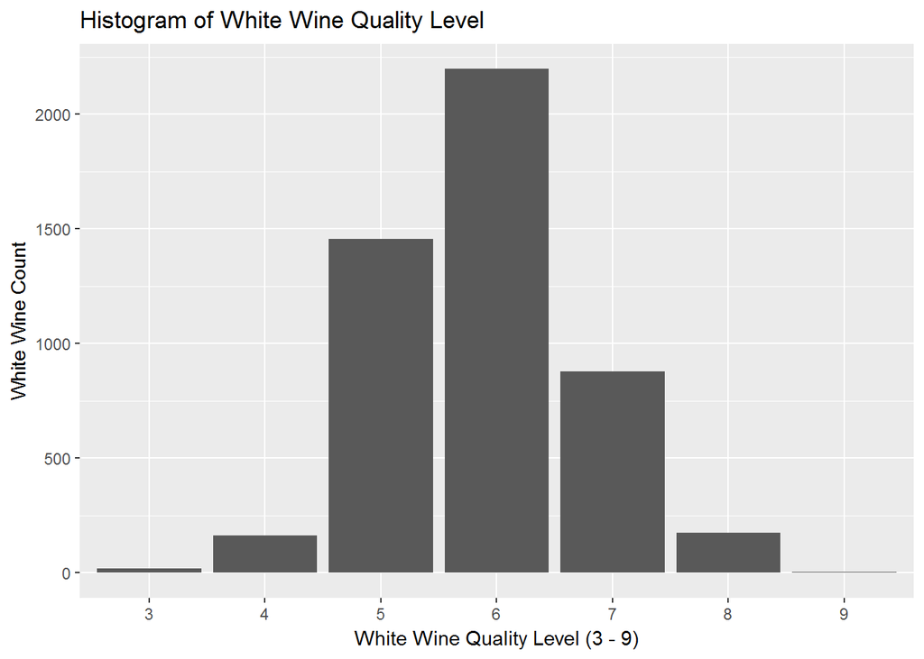

```
##    3    4    5    6    7    8    9
##   20  163 1457 2198  880  175    5
```

### Description one

This plot appears to have a normally distributed within the white wine quality level of 6. There are no white wine with quality score 0,1, 2 nor 10 stating that their is no perfect or worst white wine. This plot is important in order to understand the distribution of the quality scores.

### Plot two

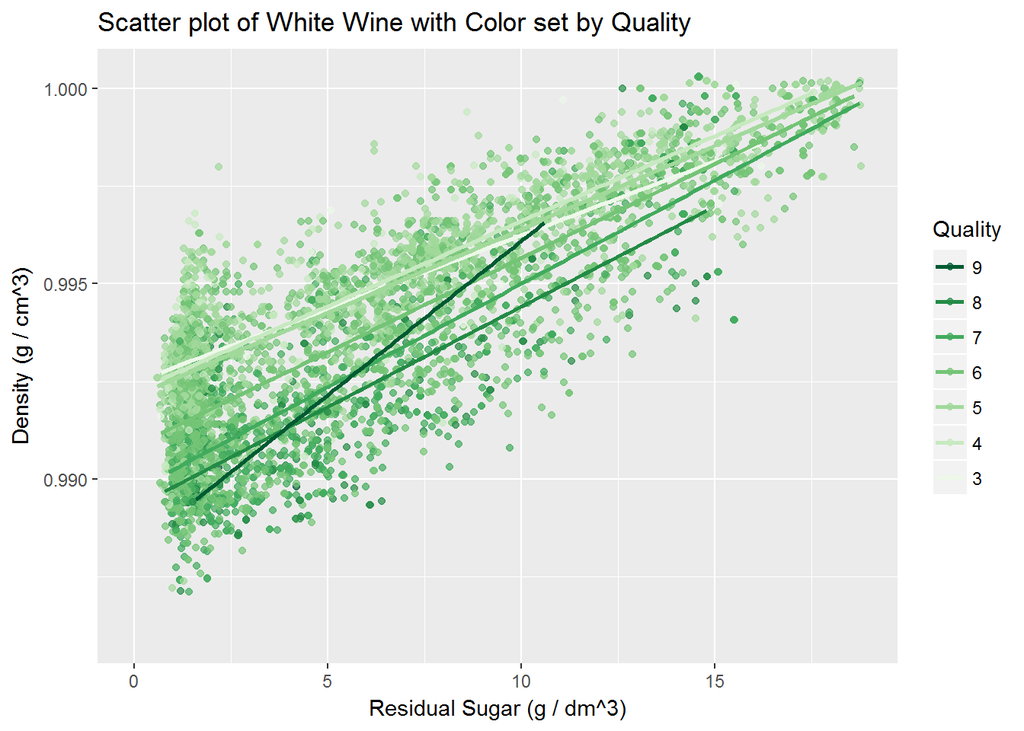

```
## [1] "Correlations between Density and Residual Sugar"
```

```
## [1] "Quality score 3 : 0.708567954467321"
## [1] "Quality score 4 : 0.745169719274969"
## [1] "Quality score 5 : 0.893388909528408"
## [1] "Quality score 6 : 0.855632919226792"
## [1] "Quality score 7 : 0.822813056675261"
## [1] "Quality score 8 : 0.818292602587863"
## [1] "Quality score 9 : 0.948667382184295"
```

### Description two

The scatter plots tells us an interesting story, although the scatter does not distinguise the quality level very well.Thus, clustering are harder for quality levels, so by graphing parameters meadian, mean, mode, and count tells us a better story for quality. This plot is a good example that our model is harder to predict quality based on the variables in this dataset.

### Plot three

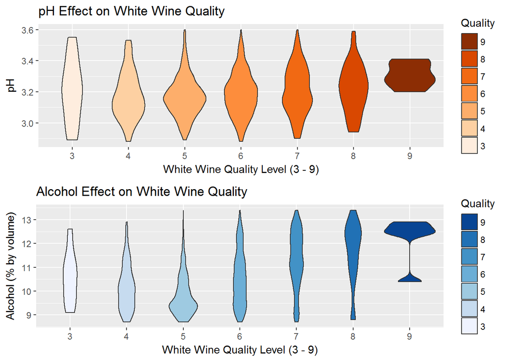

### Description three

Similarly to the traditional boxplot, a violin plot is a blend between boxplot and the density giving us a rich support of the pH effect on white wine quality. Thus wider parts in the plots indicate greater number of white wines with those values. This exact relation can be seen with Alcohol. Supporting the argument that less alcohol impless better quality in the quality range of 3-5, but in the quality range of 5-9, greather Alcohol refers to better quality. This figure supports that alcohol has a significant effect on quality.

### Summary

As shown, there are alot of variables that can define the quality of white wine. It was hard to make a significant decision whether quality had any inferences that can be made to predict white wine based on this analysis and dataset. However, it can be stated that alcohol and pH had some effects on Quality depending on the quality range. Thus the results from our linear model, we can only explain about 27.5% of quality variances. It is to believe that other variables outside of this dataset would had affect on the quality of the white wine.

# Reflection

The white wine dataset contains 4,898 white wines with 11 variables(fixed acidity, volatile acidity, citric acid, residual sugar, chlorides, free sulfur dioxide, total sulfur dioxide, density, pH, sulphates,alcohol) on quantifying the chemical properties of each wine. I began by understanding these individual variables in the dataset in order to perform and efficient analysis. This analysis made me become closer towards a frequent wine drinker, althought I was not aware of the attributes but certaintly from my own experience i am able to differenciate the quality of the wine.

Alot of plots were created in order to understand the relationship of each variables, in which by creating a correlation matrix made me understand my process throughtout the analysis.

Having an familarity with R, made it much easier to conduct this analysis. Fortunely there were many sources on the internet and R community that made it very helpful about solving any kind of problem I faced with my syntex errors.

As already mentioned in the summary section, I believe that by having additional variables outside of this dataset, it would had been helpful to build better models for instance, the type of grapes, age, duration of drinking wine etc or other chemican components of white wine for future analysis.